# Capstone Project Draft 1

Ryan Willett

Import the data and labels into two data sets.

```r
cancer_data <- read.csv("data.csv")
cancer_labels <- read.csv("labels.csv")
gene_labels <- read.csv("gene_information.csv")
```

We must assign each case and the type of cancer that it is with the gene expression data.

Unlabeled Dataset

```r
# Renaming rows to the sample ID
rownames(cancer_data) <- cancer_data$X
cancer_data$X <- NULL  # Removing the sample ID column
# Renaming the column gene number on the microarray to the gene name
colnames(cancer_data) <- gene_labels$gene_name
rm(gene_labels)
```

Labeled Dataset

```r
# Binding the tumor diagnosis to the dataset
cancer_join <- cbind(cancer_data, cancer_labels)
cancer_join$X <- NULL # Removing the X column (sample number)
rm(cancer_labels)
```

Now that we have each analyzed tumor labeled with the proper tumor type and each analyzed gene with the clear gene name.

The tumor types are: lung adenocarcinoma (**LUAD**), kidney renal clear cell carcinoma(**KIRC**), breast invasive carcinoma(**BRCA**), colon adenocarcinoma (**COAD**), prostate adenocarcinoma(**PRAD**).

https://gdc.cancer.gov/resources-tcga-users/tcga-code-tables/tcga-study-abbreviations

### Use hierarchical clustering to determine if there are relationships between the different tumor groups on the basis of gene expression.

```r
d <- dist(as.matrix(cancer_data)) #cancer_data is used so as not to bias the clustering with the known tumor classification in cancer_join
cat_n <- 5
hc <- hclust(d, method="ward.D")
hc <- as.dendrogram(hc)

#Plot the data
#cols_branches <- c("blue", "green", "red", "black", "orange")
dend <- color_branches(hc, k=cat_n, col = c("blue", "green", "red", "black", "orange"))
labels(dend) <- NULL # Remove labels because they make the image too busy
plot(dend, main = "Clustering Based on 5 Classes")
```

[output not shown]

```r
#Select out clusters based on 5 classes (because we have 5 tumor types). Bind these groups information to the original dataset
groups <- cutree(hc, k=5)
cancer_join <- cbind(cancer_join, groups)
#Selecting out the different tumor classifications based on the clustering group.
```

```r
tree_split_class <- function(dg, g) {
  hcX <- subset(dg, groups==g)
  return(hcX)
}

results <- list()
for (i in 1:cat_n) {
  results[[i]] <- tree_split_class(cancer_join$Class, i)
}
```

```r
d <- dist(as.matrix(cancer_data)) #cancer_data is used so as not to bias the clustering with the known tumor classification in cancer_join
cat_n <- 5
hc <- hclust(d, method="ward.D")
hc <- as.dendrogram(hc)
#Plot the data
#cols_branches <- c("blue", "green", "red", "black", "orange")
dend <- color_branches(hc, k=cat_n, col = c("blue", "green", "red", "black", "orange"))
labels(dend) <- NULL # Remove labels because they make the image too busy
```

```
The lengths of the new labels is shorter than the number of leaves in the dendrogram - labels are recycled.'x' is NULL so the result will be NULL
```

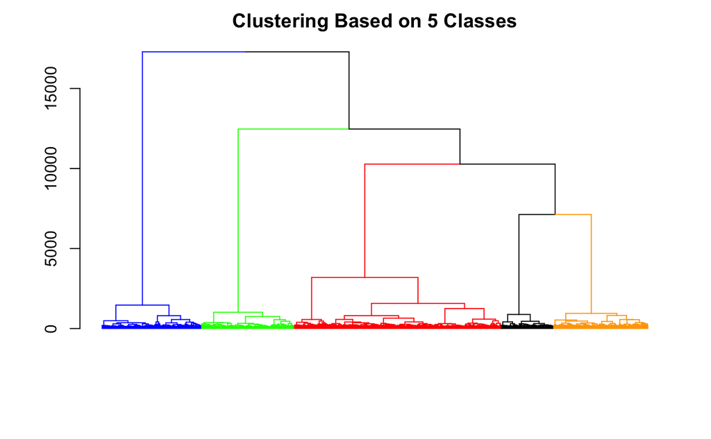

```r
plot(dend, main = "Clustering Based on 5 Classes")
```

```r
#Select out clusters based on 5 classes (because we have 5 tumor types). Bind these groups information to the original dataset
groups <- cutree(hc, k=5)
cancer_join <- cbind(cancer_join, groups)
#Selecting out the different tumor classifications based on the clustering group.
```

```r
tree_split_class <- function(dg, g) {
  hcX <- subset(dg, groups==g)
  return(hcX)
}
results <- list()
for (i in 1:cat_n) {
  results[[i]] <- tree_split_class(cancer_join$Class, i)
}
```

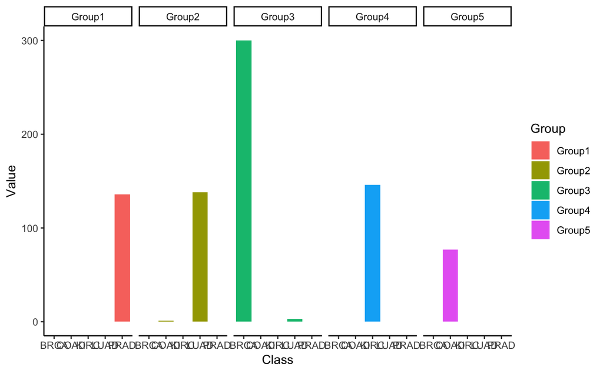

```r
class_summary <- sapply(results, table)
colnames(class_summary) <- c("Group1", "Group2", "Group3", "Group4", "Group5")
class_summary <- as.data.frame(class_summary)
class_summary$Class <- row.names(class_summary)
class_summary <- class_summary %>% gather(key="Group", value="Value", 1:5, na.rm=T)
classplot <- ggplot(class_summary, aes(x=Class, y=Value, fill=Group)) +
  facet_grid(.~ Group) +
  geom_bar(stat="identity", position = "dodge") +
  theme_classic()
classplot
```

```r
#Create loops method that quantifies each incidence of each tumor type in the cluster group.
```

```r
cancer_sample_means <- cancer_join[1:50, ] %>% group_by(Class) %>% summarise(mean())
```

```
Error in summarise_impl(.data, dots) :
  Evaluation error: argument "x" is missing, with no default.
```

```r
write.csv(cancer_sample_aov, file="cancer_aov.csv")
```

```r
anova_TP53 <- aov(TP53 ~ Class, data = cancer_join)

summary(anova_TP53)
```

[output not shown]

```r
tuk_TP53 <- TukeyHSD(anova_TP53)

tuk_TP53
```

[output not shown]

```r
#Retain the 'Class' and 'p adj' columns from the Tukey post doc results (tuk_*), step through the p adj variables and convert to dummy variables if they are signficant to a CI of 0.01.

#WORK IN PROGRESS. This blocks is functional for the gene set. Loop needs to be written to apply this method to all genes.

tuk_TP53 <- tuk_TP53$Class[,4]
tuk_TP53 <- ifelse(tuk_TP53 <= 0.01, 1, 0)

tuk_pvals <- data.frame(tuk_TP53)

#Transpose the vector so the genes are in the rows and the Tukey p-value comparisons are in the columns.
tuk_pvals <- t(tuk_pvals)
```